# hw2

## 1) Transformation of variables:

For a random uniform distribution of x between 0 and 1, the probability density function is f(x). Find the probability density function g(u) of transformation $u=e^{-x}$.

a. Show details to derive the formula g(u).

b. Draw three figures: transformation function u(x), f(x) and g(u).

## 2) Rolling two 6-sided dices.

Each of the faces has the same probability of landing facing up. Calculate analytic answers of following questions (show details).

a. What is the probability of rolling snake eyes (two 1s)?

b. What is the probability of rolling fives (dice sum to five)?

c. Rolling dices 5 times and get at least one snake eye. Is the probability larger than rolling fives?

## 3) Compare probability distribution functions

Three probability distribution functions: Binomial, Poisson and Normal function.

#### a. Binomial (N=10, p=0.02), Poisson ($\lambda=0.2$), Normal($\mu = 0.2$, $\sigma = 0.45$)

```
i) Draw 3 functions in the same plot, and scale the area under the curve of each fucntion to 1.

ii) Create a table to compare numerical values of Mean, Sigma, Skewness and Kurtosis, e.g.
```

pdf mean sigma sknewness kurtosis Binomial Poisson Normal

#### b. Binomial (N=100, p=0.02), Poisson ($\lambda$=2), Normal($\mu=2$, $\sigma=1.4$)

```
i) Draw 3 functions in the same plot, and scale the area under the curve of each fucntion to 1.

ii) Create a table to compare numerical values of Mean, Sigma, Skewness and Kurtosis for each function.
```

#### c. Binomial (N=1000, p=0.02), Poisson ($\lambda$=20), Normal($\mu=20$, $\sigma=4.5$)

```
i) Draw 3 functions in the same plot, and scale the area under the curve of each fucntion to 1.

ii) Create a table to compare numerical values of Mean, Sigma, Skewness and Kurtosis for each function.
```

```python
import numpy as np
import matplotlib.pyplot as plt
import scipy.stats as stats
import pandas as pd
```

### b.

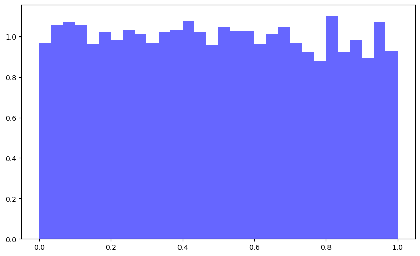

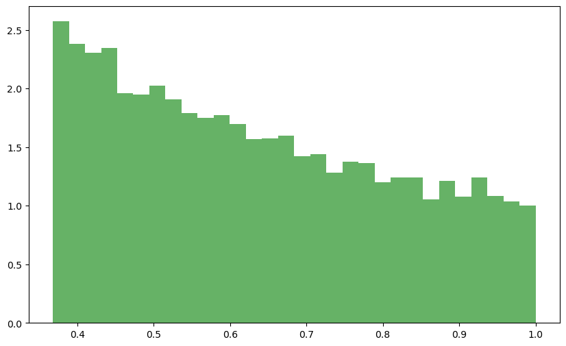

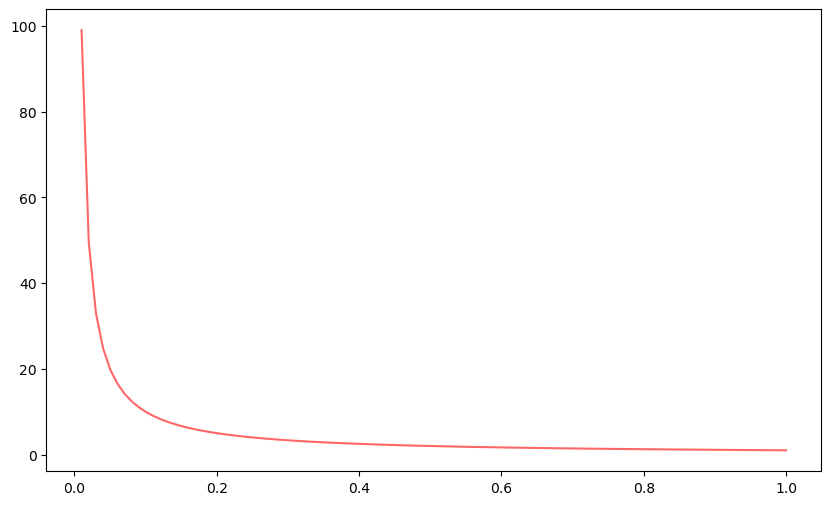

```python
# Create the sample
np.random.seed(42)
x = np.random.uniform(0, 1, 10000)
u = np.exp(-x)
u_values = np.linspace(0, 1, 100)
def g(u):
    result = 1/u
    return result

# Plot for uniform distribution
plt.figure(figsize=(10, 6))
plt.hist(x, bins=30, density=True, alpha=0.6, color='b', label='Histogram of f(x)')

# Plot the inversed function
plt.figure(figsize=(10, 6))
plt.hist(u, bins=30, density=True, alpha=0.6, color='g', label='Histogram of u(x)')


# Plot for g(u)
plt.figure(figsize=(10, 6))
plt.plot(u_values, g(u_values), alpha=0.6, color='r', label='Plot of g(u)')
```

### Question 2

#### a.

There is only one possible way out of 36 outcomes so 1/36 probability

#### b.

There are 4 possible ways out of 36 outcomes so 1/9 probability

### Question 3

```
  Distribution      Mean     Sigma  Skewness  Kurtosis
0     Binomial  0.204200  0.447552  2.119235  4.062947
1       Normal  0.198141  0.442632 -0.037053  0.118672
2      Poisson  0.203800  0.447063  2.141377  4.307039
```

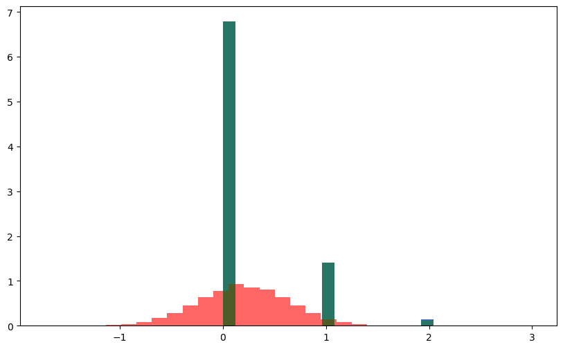

```python
### Question 3

np.random.seed(4)
N = 10
p = 0.02
M = 10000
# create the binomial distribution
binomial_samples = np.random.binomial(N, p, M)
# create the normal distribution
normal_samples = np.random.normal(N*p, np.sqrt(N*p*(1-p)), M)
# create the poisson distribution
poisson_samples = np.random.poisson(N*p, M)

plt.figure(figsize=(10, 6))
plt.hist(binomial_samples, bins=25, density=True, alpha=0.6, color='b', label='Binomial Distribution')
plt.hist(normal_samples, bins=25, density=True, alpha=0.6, color='r', label='Normal Distribution')
plt.hist(poisson_samples, bins=25, density=True, alpha=0.6, color='g', label='Poisson Distribution')

# Create table of means, sigma, skewness, and kurtosis with pandas
data = {
    'Distribution': ['Binomial', 'Normal', 'Poisson'],
    'Mean': [np.mean(binomial_samples), np.mean(normal_samples), np.mean(poisson_samples)],
    'Sigma': [np.std(binomial_samples), np.std(normal_samples), np.std(poisson_samples)],
    'Skewness': [stats.skew(binomial_samples), stats.skew(normal_samples), stats.skew(poisson_samples)],
    'Kurtosis': [stats.kurtosis(binomial_samples), stats.kurtosis(normal_samples), stats.kurtosis(poisson_samples)]
}
pd_table = pd.DataFrame(data)
print(pd_table)
```

```
  Distribution      Mean     Sigma  Skewness  Kurtosis
0     Binomial  2.000600  1.417180  0.684682  0.329207
1       Normal  1.994121  1.399726 -0.037053  0.118672
2      Poisson  2.009200  1.426294  0.711918  0.599655
```

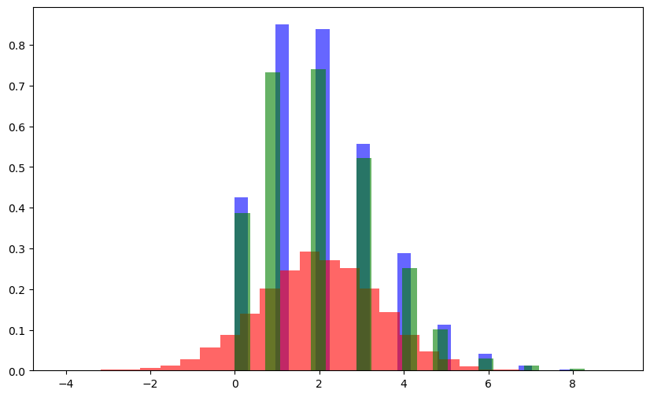

```python
# second set of parameters
np.random.seed(4)
N = 100
p = 0.02
M = 10000
# create the binomial distribution
binomial_samples = np.random.binomial(N, p, M)
# create the normal distribution
normal_samples = np.random.normal(2, 1.4, M)
# create the poisson distribution
poisson_samples = np.random.poisson(2, M)

plt.figure(figsize=(10, 6))
plt.hist(binomial_samples, bins=25, density=True, alpha=0.6, color='b', label='Binomial Distribution')
plt.hist(normal_samples, bins=25, density=True, alpha=0.6, color='r', label='Normal Distribution')
plt.hist(poisson_samples, bins=25, density=True, alpha=0.6, color='g', label='Poisson Distribution')

# Create table of means, sigma, skewness, and kurtosis with pandas
data = {
    'Distribution': ['Binomial', 'Normal', 'Poisson'],
    'Mean': [np.mean(binomial_samples), np.mean(normal_samples), np.mean(poisson_samples)],
    'Sigma': [np.std(binomial_samples), np.std(normal_samples), np.std(poisson_samples)],
    'Skewness': [stats.skew(binomial_samples), stats.skew(normal_samples), stats.skew(poisson_samples)],
    'Kurtosis': [stats.kurtosis(binomial_samples), stats.kurtosis(normal_samples), stats.kurtosis(poisson_samples)]
}
pd_table = pd.DataFrame(data)
print(pd_table)
```

```
  Distribution       Mean     Sigma  Skewness  Kurtosis
0     Binomial  19.995200  4.473005  0.229771 -0.051848
1       Normal  19.981104  4.499119 -0.037053  0.118672
2      Poisson  20.030600  4.524540  0.228575  0.057715
```

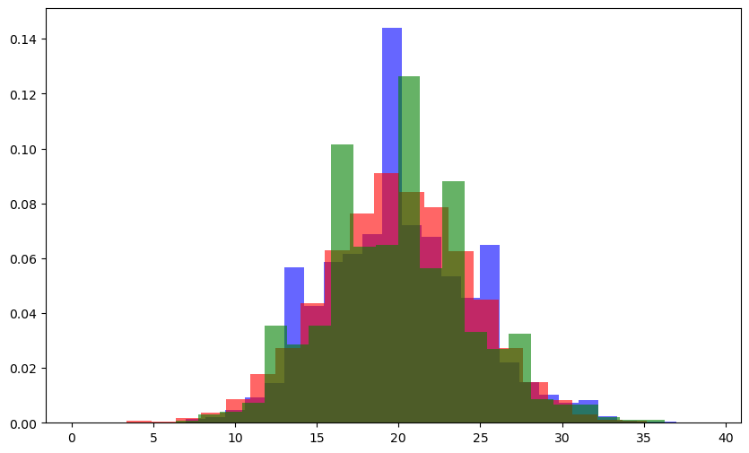

```python
# second set of parameters
np.random.seed(4)
N = 1000
p = 0.02
M = 10000
# create the binomial distribution
binomial_samples = np.random.binomial(N, p, M)
# create the normal distribution
normal_samples = np.random.normal(20, 4.5, M)
# create the poisson distribution
poisson_samples = np.random.poisson(20, M)

plt.figure(figsize=(10, 6))
plt.hist(binomial_samples, bins=25, density=True, alpha=0.6, color='b', label='Binomial Distribution')
plt.hist(normal_samples, bins=25, density=True, alpha=0.6, color='r', label='Normal Distribution')
plt.hist(poisson_samples, bins=25, density=True, alpha=0.6, color='g', label='Poisson Distribution')

# Create table of means, sigma, skewness, and kurtosis with pandas
data = {
    'Distribution': ['Binomial', 'Normal', 'Poisson'],
    'Mean': [np.mean(binomial_samples), np.mean(normal_samples), np.mean(poisson_samples)],
    'Sigma': [np.std(binomial_samples), np.std(normal_samples), np.std(poisson_samples)],
    'Skewness': [stats.skew(binomial_samples), stats.skew(normal_samples), stats.skew(poisson_samples)],
    'Kurtosis': [stats.kurtosis(binomial_samples), stats.kurtosis(normal_samples), stats.kurtosis(poisson_samples)]
}
pd_table = pd.DataFrame(data)
print(pd_table)
```